# Batch Correction

## 3. Batch correction

Note that the analysis was performed in alignment with this tutorial: http://jtleek.com/genstats/inst/doc/02_13_batch-effects.html

### A. Data preparation

Merge all by common ID

```r
all_data = list(gse17708, gse17518, merged, keshamouni) %>% reduce(full_join, by = "ID")
```

Construct the pheno data mapping.

```r
sample = c("GSE17708_Early", "GSE17708_1_hr", "GSE17708_2_hr", "GSE17708_4_hr", "GSE17708_8_hr", "GSE17708_16_hr", "GSE17708_24_hr", "GSE17708_End",
                "GSE17518_End",
                "Garcia_Early",  "Garcia_1_hr", "Garcia_24_hr", "Garcia_End",
                "Keshamouni_End")
expt =  c("GSE17708", "GSE17708", "GSE17708", "GSE17708", "GSE17708", "GSE17708", "GSE17708", "GSE17708",
                "GSE17518",
                "Garcia",  "Garcia", "Garcia", "Garcia",
                "Keshamouni")
timeCourse = c("Early", "1hr", "2hr", "4hr", "8hr", "16hr", "24hr", "End",
              "End",
               "Early", "1hr", "24hr", "End",
               "End")
omicsType = c("RNA", "RNA", "RNA", "RNA", "RNA", "RNA", "RNA", "RNA",
              "RNA",
              "Protein", "Protein", "Protein", "Protein",
              "Protein")
```

This formats the expression data.

```r
ids = all_data$ID
all_data = subset(all_data, select=-c(ID))
row.names(all_data) = as.factor(ids)
all_data[is.na(all_data)] = 0
```

Construct the pheno data object.

```r
p = data.frame(
  row.names=sample,
  expt=expt,
  time=timeCourse,
  omics=omicsType
)

metadata = data.frame(labelDescriptions=c("time", "experiments", "omics"))
pdata = AnnotatedDataFrame(data=p, varMetadata=metadata)
```

Now we’ll begin constructing the expression set for limma voom and ComBat.

```r
library(sva)
library(Biobase)
```

Ensure the data is numeric.

```r
all_data = sapply(all_data, as.numeric)
```

Construct the expression set and related variables.

```r
data = ExpressionSet(assayData=as.matrix(all_data), phenoData=pdata)

pheno = pData(data)
edata = exprs(data)
```

### B. Use linear model to adjust for batch effects

This uses the time, omics, and experiment variables.

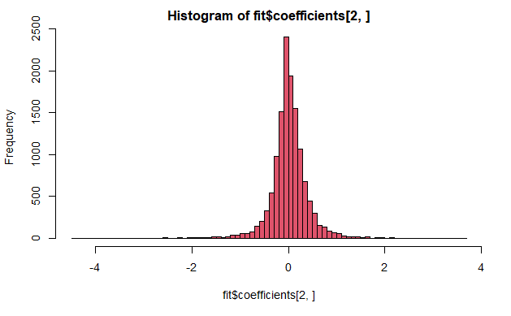

```r
mod = model.matrix(~as.factor(time) + as.factor(omics) + as.factor(expt), data=pheno)
fit = lm.fit(mod, t(edata))
hist(fit$coefficients[2,],col=2,breaks=100)
```

### C. Use ComBat to adjust for batch effects

This approach uses ComBat instead of a linear model (limma-voom)

```r
batch = pheno$expt
modcombat = model.matrix(~1, data=pheno)
modtime = model.matrix(~time, data=pheno)
combat_edata = ComBat(dat=edata, batch=batch, mod=modcombat, par.prior=TRUE, prior.plots=FALSE)
```

```
Found 11422 genes with uniform expression within a single batch (all zeros); these will not be adjusted for batch.
```

```
Using the 'mean only' version of ComBat
Found4batches
Note: one batch has only one sample, setting mean.only=TRUE
Adjusting for0covariate(s) or covariate level(s)
Standardizing Data across genes
Fitting L/S model and finding priors
Finding parametric adjustments
Adjusting the Data
```

Now fit the linear model.

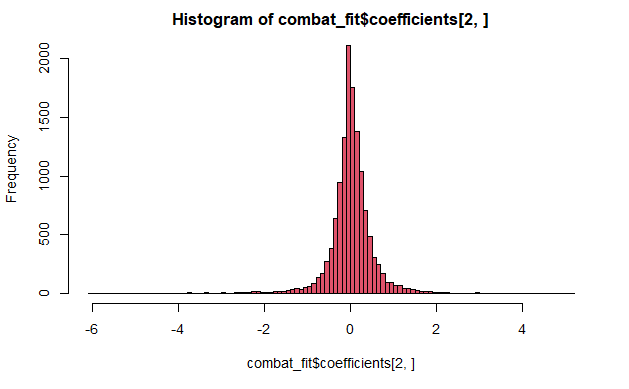

```r
combat_fit = lm.fit(modtime, t(combat_edata))
hist(combat_fit$coefficients[2,],col=2,breaks=100)
```

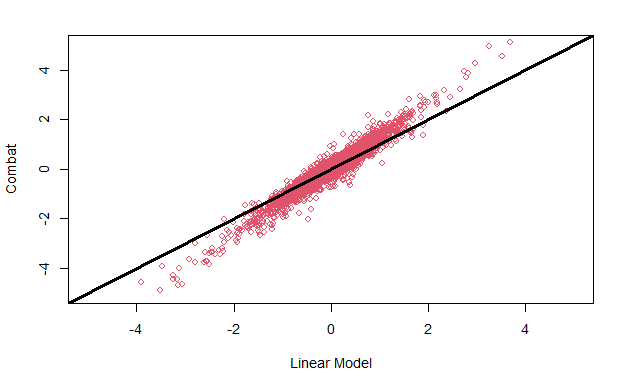

```r
plot(
      fit$coefficients[2,], combat_fit$coefficients[2,],
      col=2,
      xlab="Linear Model", ylab="Combat",
      xlim=c(-5,5), ylim=c(-5,5)
     )
abline(c(0,1),col=1,lwd=3)
```

They’re very similar.

### D. Surrogate Variable Analysis

This is another method that tries to automatically discover the batch effect.

```r
library("limma")
library("reshape2")
library("ggplot2")
mod = model.matrix(~as.factor(expt), data=pheno)
mod0 = model.matrix(~1, data=pheno)

sva1 = sva(edata, mod, mod0)
```

```
Number of significant surrogate variables is:  2
Iteration (out of 5 ):
```

```
Error in density.default(x, adjust = adj) : 'x' contains missing values
```

```r
sva1$sv
cov = cbind(sva1$sv[, 1:sva1$n.sv])
norm_values = removeBatchEffect(edata, covariates=cov)
tmp = melt(norm_values)
tmp$value = as.numeric(tmp$value)
ggplot(tmp, aes(x=value, fill=Var2)) + geom_histogram(bins=100)
```

[output not shown]

```r
pvalue = data.frame(2*pnorm(abs(norm_values), lower.tail=FALSE))
row.names(pvalue) = ids
row.names(norm_values) = ids
colnames(pvalue) = colnames(norm_values)
write.csv(norm_values, "C:/Users/Scott/Desktop/ComBat_EMT_fitted.csv")
write.csv(pvalue, "C:/Users/Scott/Desktop/ComBat_EMT_pvalue.csv")
```